# Outpatient Survey Analysis

Anupam kumar Singh, MD

28 October 2017

The outpatient health survey was conducted to assess satisfaction levels of patients in our jhajjar outreach clinic. The questionaire was adapted from a pre-existing questionaire made of 23 questions with sub-domains evaluating Interpersonal Skills, Physical Environment , Availability, Quality and Accessibility on a Likert scale. One question evaluated overall global satisfaction with physician. Our Goal in this study is to

1. Assess Distribution of Scores across various questions.
2. Assess Distribution of Scores across sub-domains.
3. correlation of of age,education and income with mean score
4. Assess which sub-domain has highest score and conduct an Anova analysis.
5. Evaluate how the various sub-domains affect via multiple linear regression.
6. Assess if five domains distinguish themselves on confirmatory factor analysis.
7. Test Divergent validity, cronbach alpha

so lets get started

### Assess Distribution of Scores across various questions

```r
jhar %>% dplyr::dplyr::select(one:Twenty.three) %>% gather(key="Question" ,value="Score") %>% group_by(Question,Score) %>% count()
```

Let us see summary of scores

```r
jhar6= read.csv("jhar6.csv")
jharx= read.csv("jharx.csv")


jhar= read.csv("jhar.csv")


jhar %>% dplyr::select(one:Twenty.three) %>% summary()
```

```
##       one             Two            Three           Four
##  Min.   :1.000   Min.   :1.000   Min.   :1.00   Min.   :1.000
##  1st Qu.:4.000   1st Qu.:4.000   1st Qu.:4.00   1st Qu.:4.000
##  Median :5.000   Median :5.000   Median :5.00   Median :5.000
##  Mean   :4.687   Mean   :4.565   Mean   :4.56   Mean   :4.644
##  3rd Qu.:5.000   3rd Qu.:5.000   3rd Qu.:5.00   3rd Qu.:5.000
##  Max.   :5.000   Max.   :5.000   Max.   :5.00   Max.   :5.000
##       Five           Six            Seven           Eight
##  Min.   :1.00   Min.   :1.000   Min.   :1.000   Min.   :1.000
##  1st Qu.:4.00   1st Qu.:4.000   1st Qu.:4.000   1st Qu.:4.000
##  Median :5.00   Median :5.000   Median :4.000   Median :4.000
##  Mean   :4.46   Mean   :4.393   Mean   :4.119   Mean   :4.266
##  3rd Qu.:5.00   3rd Qu.:5.000   3rd Qu.:5.000   3rd Qu.:5.000
##  Max.   :5.00   Max.   :5.000   Max.   :5.000   Max.   :5.000
##       Nine            Ten           Eleven          Twelve
##  Min.   :1.000   Min.   :1.00   Min.   :1.000   Min.   :1.000
##  1st Qu.:4.000   1st Qu.:4.00   1st Qu.:4.000   1st Qu.:4.000
##  Median :5.000   Median :5.00   Median :5.000   Median :4.000
##  Mean   :4.251   Mean   :4.54   Mean   :4.485   Mean   :4.119
##  3rd Qu.:5.000   3rd Qu.:5.00   3rd Qu.:5.000   3rd Qu.:5.000
##  Max.   :5.000   Max.   :5.00   Max.   :5.000   Max.   :5.000
##     Thirteen        Fourteen        Fifteen         Sixteen
##  Min.   :1.000   Min.   :1.000   Min.   :1.000   Min.   :1.00
##  1st Qu.:4.000   1st Qu.:4.000   1st Qu.:4.000   1st Qu.:4.00
##  Median :5.000   Median :5.000   Median :4.000   Median :5.00
##  Mean   :4.465   Mean   :4.453   Mean   :4.284   Mean   :4.54
##  3rd Qu.:5.000   3rd Qu.:5.000   3rd Qu.:5.000   3rd Qu.:5.00
##  Max.   :5.000   Max.   :5.000   Max.   :5.000   Max.   :6.00
##    Seventeen        Eighteen       Nineteen        Twenty
##  Min.   :1.000   Min.   :1.00   Min.   :1.00   Min.   :1.00
##  1st Qu.:4.000   1st Qu.:4.00   1st Qu.:4.00   1st Qu.:4.00
##  Median :5.000   Median :5.00   Median :5.00   Median :5.00
##  Mean   :4.537   Mean   :4.53   Mean   :4.58   Mean   :4.49
##  3rd Qu.:5.000   3rd Qu.:5.00   3rd Qu.:5.00   3rd Qu.:5.00
##  Max.   :5.000   Max.   :5.00   Max.   :5.00   Max.   :5.00
##    Twenty.one     twenty.two     Twenty.three
##  Min.   :1.00   Min.   :1.000   Min.   :1.000
##  1st Qu.:4.00   1st Qu.:4.000   1st Qu.:4.000
##  Median :5.00   Median :5.000   Median :5.000
##  Mean   :4.51   Mean   :4.577   Mean   :4.532
##  3rd Qu.:5.00   3rd Qu.:5.000   3rd Qu.:5.000
##  Max.   :5.00   Max.   :5.000   Max.   :5.000
```

```r
jhar %>% dplyr::select(one:Twenty.three) %>%map(~skewness(.))
```

```
## $one
## [1] -2.595851
##
## $Two
## [1] -1.799874
##
## $Three
## [1] -1.662334
##
## $Four
## [1] -1.985509
##
## $Five
## [1] -1.70078
##
## $Six
## [1] -1.405989
##
## $Seven
## [1] -0.8816675
##
## $Eight
## [1] -1.387662
##
## $Nine
## [1] -1.117693
##
## $Ten
## [1] -1.294795
##
## $Eleven
## [1] -1.582273
##
## $Twelve
## [1] -1.196617
##
## $Thirteen
## [1] -1.403634
##
## $Fourteen
```

[output cut: 13 more lines]

```
##
## $Nineteen
## [1] -1.686639
##
## $Twenty
## [1] -1.780721
##
## $Twenty.one
## [1] -1.612736
##
## $twenty.two
## [1] -1.858309
##
## $Twenty.three
## [1] -1.54983
```

Let us look at joy plot which indicate bimodal peaks at 4 and 5 indicating Very satisfied(5) or Satisfied patients(4).

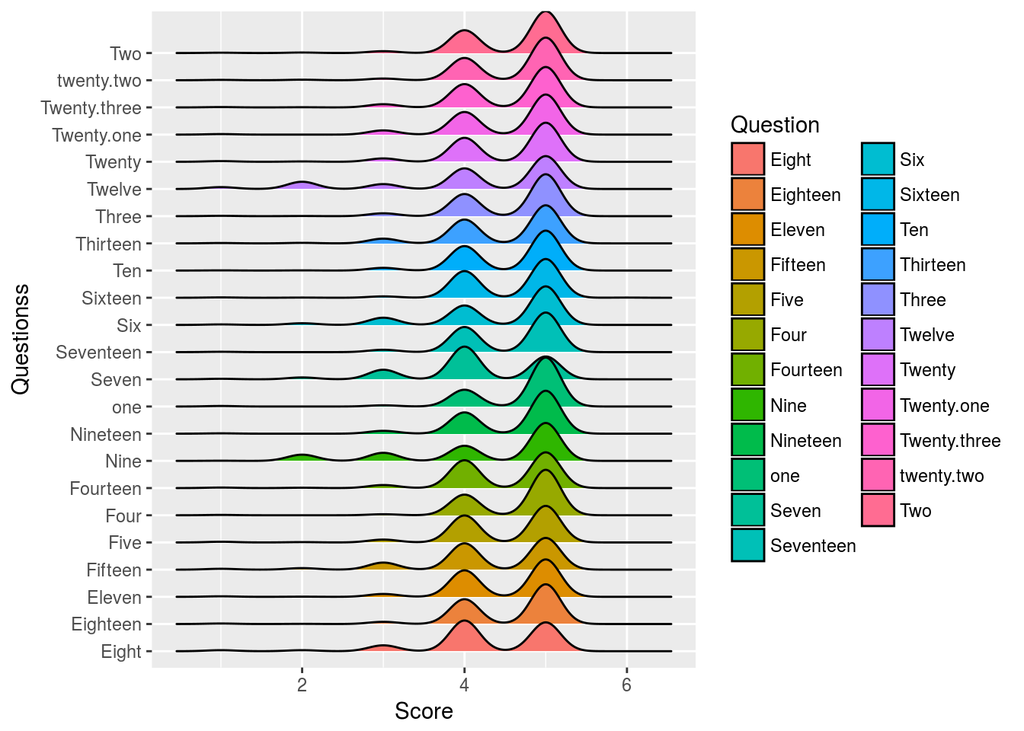

Let us look at percent of neutral/dissasatisfied responses across various questions

```r
jhar %>% dplyr::select(one:Twenty.three) %>% gather(key="Question" ,value="Score") %>% group_by(Question) %>% summarise(Neutral_dissatisfied_percent = mean(Score<4)) %>% arrange(desc(Neutral_dissatisfied_percent))
```

```
## # A tibble: 23 x 2
##      Question Neutral_dissatisfied_percent
##         <chr>                        <dbl>
##  1       Nine                   0.21393035
##  2     Twelve                   0.20646766
##  3      Seven                   0.17661692
##  4    Fifteen                   0.13930348
##  5        Six                   0.13930348
##  6      Eight                   0.11691542
##  7   Thirteen                   0.08208955
##  8 Twenty.one                   0.06965174
##  9     Twenty                   0.06467662
## 10       Five                   0.05721393
## # ... with 13 more rows
```

So question 6,7,8,9,12 and 15 have neutral/dissatisfied reponses from greater than 10% of patients and we need to improve on these parameters.

Let us see which questions have the highest percent of very satisfied(5) score.

```r
jhar %>% dplyr::select(one:Twenty.three) %>% gather(key="Question" ,value="Score") %>% group_by(Question) %>% summarise(very_satisfied_percent = mean(Score==5)) %>% arrange(desc(very_satisfied_percent))
```

```
## # A tibble: 23 x 2
##        Question very_satisfied_percent
##           <chr>                  <dbl>
##  1          one              0.7263682
##  2         Four              0.6741294
##  3     Nineteen              0.6368159
##  4   twenty.two              0.6318408
##  5        Three              0.6218905
##  6          Two              0.6218905
##  7 Twenty.three              0.5995025
##  8   Twenty.one              0.5945274
##  9          Ten              0.5920398
## 10     Eighteen              0.5895522
## # ... with 13 more rows
```

```r
jhar6 %>% dplyr::select(one:Twenty.three) %>% sjp.likert(values = "hide")
```

[output not shown]

Let us look at distribution of score across domains . First the visualisation

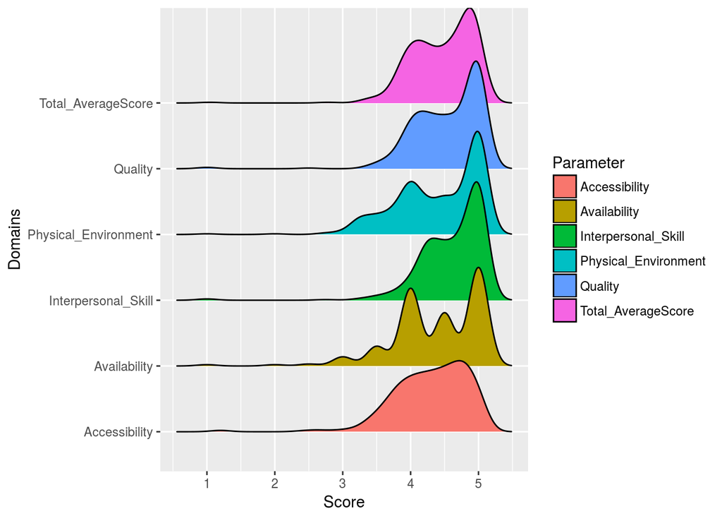

```r
jhar %>% dplyr::select(Accessibility,Quality,Physical_Environment,Interpersonal,Availability,MeanScore) %>% rename(Interpersonal_Skill = Interpersonal,Total_AverageScore=MeanScore) %>% gather("Parameter","Score",1:6) %>% ggplot(aes(x = Score, y = as.factor(Parameter),fill=Parameter)) + geom_joy()+
  labs(x = "Score",y = "Domains")
```

Now statistics part

```r
jhar %>% dplyr::select(Accessibility,Quality,Physical_Environment,Interpersonal,Availability,MeanScore)  %>% summary()
```

```
##  Accessibility      Quality      Physical_Environment Interpersonal
##  Min.   :1.200   Min.   :1.000   Min.   :1.000        Min.   :1.000
##  1st Qu.:4.000   1st Qu.:4.250   1st Qu.:4.000        1st Qu.:4.250
##  Median :4.400   Median :4.625   Median :4.500        Median :4.750
##  Mean   :4.298   Mean   :4.537   Mean   :4.402        Mean   :4.614
##  3rd Qu.:4.800   3rd Qu.:5.000   3rd Qu.:5.000        3rd Qu.:5.000
##  Max.   :5.000   Max.   :5.000   Max.   :5.000        Max.   :5.000
##   Availability     MeanScore
##  Min.   :1.000   Min.   :1.043
##  1st Qu.:4.000   1st Qu.:4.130
##  Median :4.500   Median :4.543
##  Mean   :4.368   Mean   :4.464
##  3rd Qu.:5.000   3rd Qu.:4.870
##  Max.   :5.000   Max.   :5.043
```

## Is there any difference in scores across domains ? Are we scoring better on some domains and lagging on others ?

We need to conduct an ANOVA test to see it..and Tukey’s post Hoc correction to see intergroup differences

```r
df =jhar %>% dplyr::select(Accessibility,Quality,Physical_Environment,Interpersonal,Availability) %>% gather(key="Domains",value = "Score")
fitaov = aov(Score~Domains,data=df)
summary(fitaov)
```

```
##               Df Sum Sq Mean Sq F value Pr(>F)
## Domains        4   26.6   6.661   21.05 <2e-16 ***
## Residuals   2005  634.4   0.316
## ---
## Signif. codes:  0 '***' 0.001 '**' 0.01 '*' 0.05 '.' 0.1 ' ' 1
```

So on ANOVA we see that there is significant difference across Domain Scores. (p<0.00001). Now we need to determine post-hoc difference after adjusting for multiple comparison by Tukey’s Method

```r
TukeyHSD(fitaov)
```

```
##   Tukey multiple comparisons of means
##     95% family-wise confidence level
##
## Fit: aov(formula = Score ~ Domains, data = df)
##
## $Domains
##                                           diff          lwr         upr
## Availability-Accessibility          0.07014925 -0.038178796  0.17847730
## Interpersonal-Accessibility         0.31579602  0.207467971  0.42412407
## Physical_Environment-Accessibility  0.10435323 -0.003974815  0.21268128
## Quality-Accessibility               0.23899254  0.130664488  0.34732059
## Interpersonal-Availability          0.24564677  0.137318717  0.35397482
## Physical_Environment-Availability   0.03420398 -0.074124069  0.14253203
## Quality-Availability                0.16884328  0.060515234  0.27717133
## Physical_Environment-Interpersonal -0.21144279 -0.319770835 -0.10311474
## Quality-Interpersonal              -0.07680348 -0.185131532  0.03152457
## Quality-Physical_Environment        0.13463930  0.026311254  0.24296735
##                                        p adj
## Availability-Accessibility         0.3926757
## Interpersonal-Accessibility        0.0000000
## Physical_Environment-Accessibility 0.0653889
## Quality-Accessibility              0.0000000
## Interpersonal-Availability         0.0000000
## Physical_Environment-Availability  0.9106676
## Quality-Availability               0.0002115
## Physical_Environment-Interpersonal 0.0000011
## Quality-Interpersonal              0.2986533
## Quality-Physical_Environment       0.0063212
```

we see Quality and Interpersonal skills domains have significant higher scores than other domains like Availability,Accessibility and Physical Environment though there is not a statistically significant difference between Quality and Interpersonal Skills.

## Correlation of Individual Domains with predictor variables like age,gender,Income,Education with individual Domain Scores and inter-Domain Correlation

```r
library(Hmisc)
flattenCorrMatrix <- function(cormat, pmat) {
  ut <- upper.tri(cormat)
  data.frame(
    row = rownames(cormat)[row(cormat)[ut]],
    column = rownames(cormat)[col(cormat)[ut]],
    cor  =(cormat)[ut],
    p = pmat[ut]
    )
}

df2 = jhar %>% dplyr::select(Age,Income,Occupation,Education,Accessibility,Quality,Physical_Environment,Interpersonal,Availability)
res2<-rcorr(as.matrix(df2[,1:9]))
flattenCorrMatrix(res2$r, round(res2$P,3)) %>% arrange(desc(p))
```

```
##                     row               column         cor     p
## 1                   Age               Income -0.01599744 0.749
## 2                Income            Education  0.02827840 0.572
## 3                   Age        Accessibility -0.03505922 0.483
## 4                Income           Occupation -0.05451126 0.276
## 5            Occupation        Accessibility  0.06554248 0.190
## 6            Occupation        Interpersonal  0.06619538 0.185
## 7                   Age Physical_Environment -0.07169959 0.151
## 8                   Age           Occupation -0.08336982 0.095
## 9            Occupation              Quality  0.09402740 0.060
## 10           Occupation         Availability  0.09441951 0.059
## 11                  Age        Interpersonal -0.09851158 0.048
## 12                  Age              Quality -0.11185898 0.025
## 13            Education        Interpersonal  0.11821669 0.018
## 14           Occupation Physical_Environment  0.12015326 0.016
```

[output cut: 22 more lines]

Let us plot a correlogram

```r
library(corrplot)
df3 = jhar %>% dplyr::select(Age,Income,Occupation,Education,one:Twenty.three)
M<-cor(df3)
head(round(M,2))
```

```
##              Age Income Occupation Education   one   Two Three  Four  Five
## Age         1.00  -0.02      -0.08     -0.43 -0.08 -0.06 -0.08 -0.09 -0.16
## Income     -0.02   1.00      -0.05      0.03  0.21  0.09  0.11  0.07  0.14
## Occupation -0.08  -0.05       1.00      0.38  0.03  0.03  0.06  0.09  0.05
## Education  -0.43   0.03       0.38      1.00  0.07  0.08  0.05  0.18  0.15
## one        -0.08   0.21       0.03      0.07  1.00  0.43  0.55  0.37  0.41
## Two        -0.06   0.09       0.03      0.08  0.43  1.00  0.50  0.56  0.44
##             Six Seven Eight Nine  Ten Eleven Twelve Thirteen Fourteen
## Age        0.00  0.04 -0.02 0.00 0.02  -0.02  -0.10    -0.09    -0.12
## Income     0.11  0.24  0.19 0.01 0.09   0.12   0.07     0.16     0.14
## Occupation 0.04  0.02  0.09 0.02 0.09   0.07   0.09     0.14     0.11
## Education  0.13  0.06  0.05 0.07 0.15   0.14   0.17     0.15     0.19
## one        0.39  0.41  0.36 0.14 0.31   0.39   0.39     0.47     0.47
## Two        0.47  0.40  0.32 0.16 0.37   0.48   0.49     0.48     0.47
##            Fifteen Sixteen Seventeen Eighteen Nineteen Twenty Twenty.one
## Age          -0.13   -0.07     -0.10    -0.12    -0.06  -0.10      -0.12
## Income        0.21    0.13      0.12     0.11     0.08   0.14       0.13
## Occupation    0.06    0.07      0.10     0.05     0.04   0.09       0.12
## Education     0.13    0.12      0.11     0.17     0.09   0.15       0.16
## one           0.43    0.47      0.43     0.52     0.40   0.43       0.42
## Two           0.42    0.43      0.40     0.43     0.44   0.44       0.52
##            twenty.two Twenty.three
## Age             -0.06        -0.07
## Income           0.07         0.12
## Occupation       0.08         0.04
## Education        0.18         0.14
## one              0.39         0.41
## Two              0.48         0.52
```

```r
corrplot(M, method="number")
```

[output not shown]

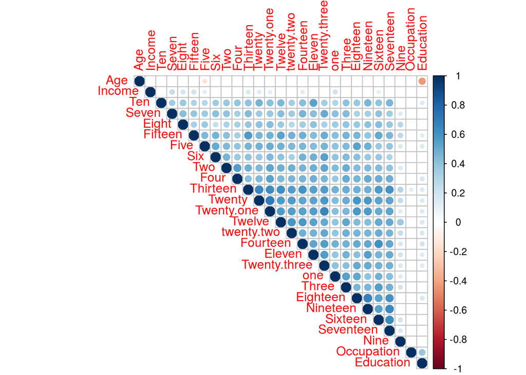

```r
cor.mtest <- function(mat, ...) {
    mat <- as.matrix(mat)
    n <- ncol(mat)
    p.mat<- matrix(NA, n, n)
    diag(p.mat) <- 0
    for (i in 1:(n - 1)) {
        for (j in (i + 1):n) {
            tmp <- cor.test(mat[, i], mat[, j], ...)
            p.mat[i, j] <- p.mat[j, i] <- tmp$p.value
        }
    }
  colnames(p.mat) <- rownames(p.mat) <- colnames(mat)
  p.mat
}
# matrix of the p-value of the correlation
p.mat <- cor.mtest(df3)

corrplot(M, type="upper", order="hclust",
         p.mat = p.mat, sig.level = 0.01, insig = "blank")
```

Now having visualised correlation plots and predictors affecting them , let’s go to factors affecting mean score

```r
library(arm)
fit=lm(MeanScore~Interpersonal+Accessibility+Physical_Environment+Availability+Quality+Sex+Age+Income+Education,data=jhar6)

summary(fit)
```

```
##
## Call:
## lm(formula = MeanScore ~ Interpersonal + Accessibility + Physical_Environment +
##     Availability + Quality + Sex + Age + Income + Education,
##     data = jhar6)
##
## Residuals:
##      Min       1Q   Median       3Q      Max
## -0.28504 -0.02039  0.00438  0.01799  1.23743
##
## Coefficients:
##                        Estimate Std. Error t value Pr(>|t|)
## (Intercept)           3.350e-01  3.953e-02   8.474 4.86e-16 ***
## Interpersonal         1.230e-01  1.211e-02  10.163  < 2e-16 ***
## Accessibility         1.997e-01  1.011e-02  19.745  < 2e-16 ***
## Physical_Environment  2.232e-01  1.074e-02  20.779  < 2e-16 ***
## Availability          8.339e-02  8.786e-03   9.492  < 2e-16 ***
## Quality               2.946e-01  1.372e-02  21.479  < 2e-16 ***
## SexM                  3.087e-03  7.491e-03   0.412    0.680
## Age                  -1.172e-06  2.517e-04  -0.005    0.996
## Income                3.803e-03  3.543e-03   1.073    0.284
## Education             3.261e-03  2.442e-03   1.336    0.182
## ---
## Signif. codes:  0 '***' 0.001 '**' 0.01 '*' 0.05 '.' 0.1 ' ' 1
##
## Residual standard error: 0.07045 on 392 degrees of freedom
## Multiple R-squared:  0.9768, Adjusted R-squared:  0.9762
## F-statistic:  1830 on 9 and 392 DF,  p-value: < 2.2e-16
```

We see that after controlling for Domain average score, age ,occupation and Income,education dont impact mean score

A cleaner output here

```r
display(fit)
```

```
## lm(formula = MeanScore ~ Interpersonal + Accessibility + Physical_Environment +
##     Availability + Quality + Sex + Age + Income + Education,
##     data = jhar6)
##                      coef.est coef.se
## (Intercept)          0.33     0.04
## Interpersonal        0.12     0.01
## Accessibility        0.20     0.01
## Physical_Environment 0.22     0.01
## Availability         0.08     0.01
## Quality              0.29     0.01
## SexM                 0.00     0.01
## Age                  0.00     0.00
## Income               0.00     0.00
## Education            0.00     0.00
## ---
## n = 402, k = 10
## residual sd = 0.07, R-Squared = 0.98
```

It implies that one point improvement in Quality will lead to 0.29 point improvement in mean score while controlling for other variables. Corresponding values for other domains are 0.22 for physical environment , 0.20 for Accessibility, 0.08 for Availability and 0.12 for Interpersonal skills other variables are non-significant. It implies Quality and Physical environment play a major role in affecting average score in our study

Let us visualise the linear regression as forest plot to emphasise this impression.

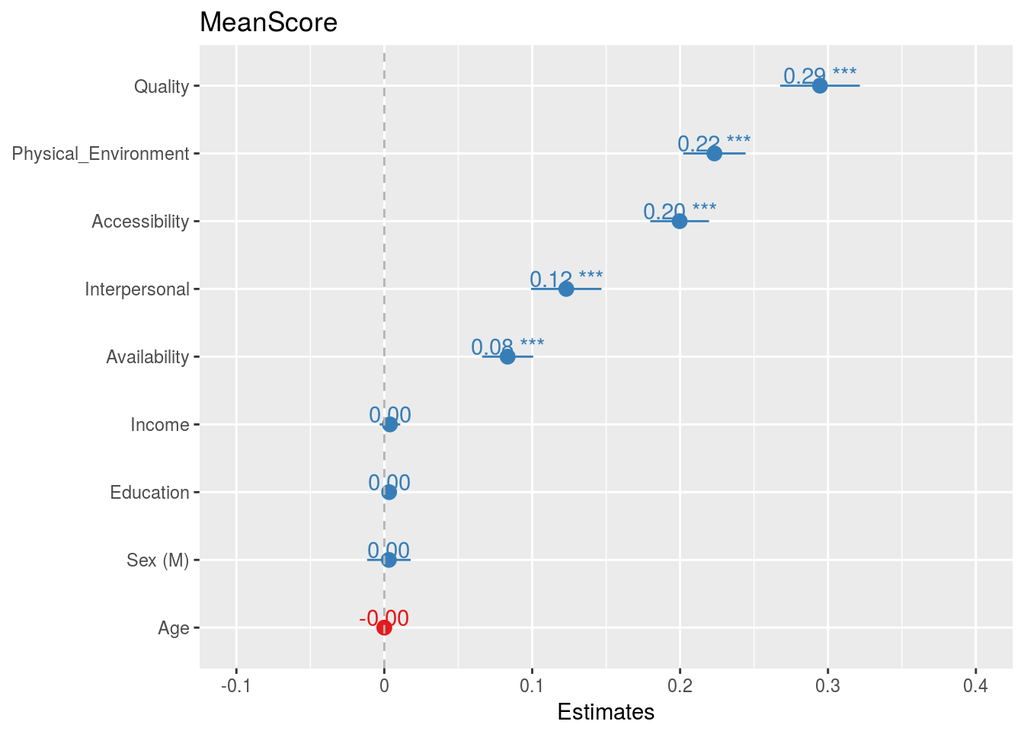

```r
sjp.lm(fit)
```

### CONFIRMATORY FACTOR ANALYSIS

Since this core was adapted from a score used in thailand outpatient set up . One of our goals is to evaluate construct validity and if the domains differentiate between each other to five domains

```r
library(psych)
library(GPArotation)
parallel <- fa.parallel(jharx, fm = 'minres', fa = 'fa')
```

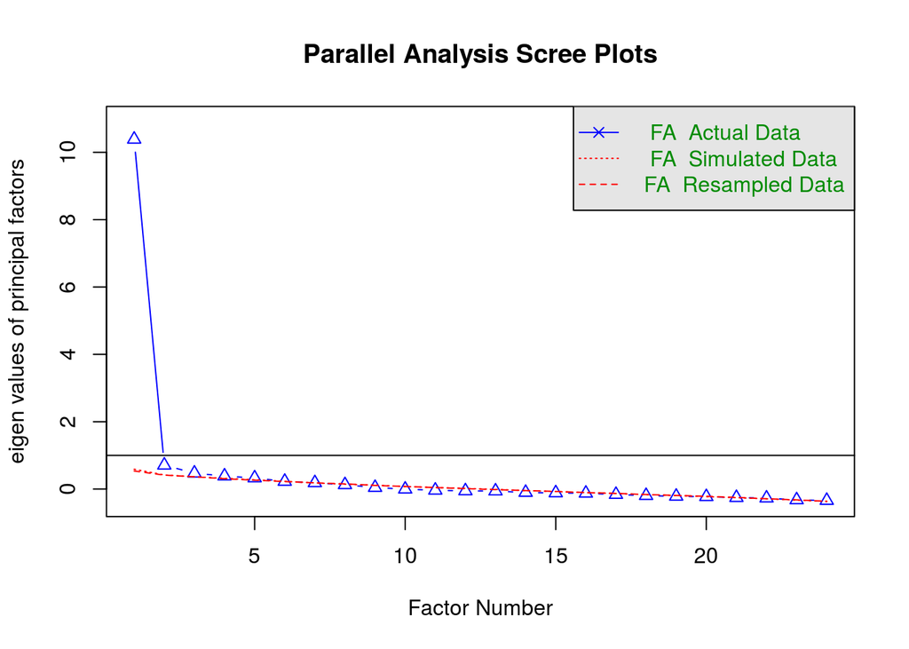

```
## Parallel analysis suggests that the number of factors =  5  and the number of components =  NA
```

The blue line shows eigenvalues of actual data and the two red lines (placed on top of each other) show simulated and resampled data. Here we look at the large drops in the actual data and spot the point where it levels off to the right. Also we locate the point of inflection – the point where the gap between simulated data and actual data tends to be minimum.

In this case, we will dplyr::select oblique rotation (rotate = “oblimin”) as we believe that there is correlation in the factors. Note that Varimax rotation is used under the assumption that the factors are completely uncorrelated. We will use Ordinary Least Squared/Minres factoring (fm = “minres”), as it is known to provide results similar to Maximum Likelihood without assuming multivariate normal distribution and derives solutions through iterative eigendecomposition like principal axis.

```r
fivefactor <- fa(jharx,nfactors = 5,rotate = "oblimin",fm="minres")
print(fivefactor)
```

```r
sixfactor <- fa(jharx,nfactors = 6,rotate = "oblimin",fm="minres")
print(sixfactor)
```

```r
print(sixfactor$loadings,cutoff = 0.3)
```

```r
jharm = as.matrix(jharx)
cortest.bartlett(jharx)
```

```
## R was not square, finding R from data
```

```
## $chisq
## [1] 5295.678
##
## $p.value
## [1] 0
##
## $df
## [1] 276
```

```r
km =kmo(jharx)

list(km$overall,km$report,km$individual)
```

```
## [[1]]
## [1] 0.954155
##
## [[2]]
## [1] "The KMO test yields a degree of common variance marvelous."
##
## [[3]]
##            X          one          Two        Three         Four
##    0.8271621    0.9600921    0.9688859    0.9619139    0.9619071
##         Five          Six        Seven        Eight         Nine
##    0.9590314    0.9383805    0.9439488    0.9319054    0.8323736
##          Ten       Eleven       Twelve     Thirteen     Fourteen
##    0.9399816    0.9629930    0.9597399    0.9632573    0.9713668
##      Fifteen      Sixteen    Seventeen     Eighteen     Nineteen
##    0.9661195    0.9553893    0.9499095    0.9450933    0.9510554
##       Twenty   Twenty.one   twenty.two Twenty.three
##    0.9552838    0.9545005    0.9706909    0.9572043
```

So Both KMO test and barlett test significant.

```r
pc2 <- principal(jharx, nfactors=length(jharx), rotate="none")
pc2
```

```r
pc3 <- principal(jharx, nfactors=5, rotate="oblimin")
pc3
```

```
## Principal Components Analysis
## Call: principal(r = jharx, nfactors = 5, rotate = "oblimin")
## Standardized loadings (pattern matrix) based upon correlation matrix
##                TC1   TC5   TC3   TC4   TC2   h2   u2 com
## X            -0.04  0.22  0.28  0.12  0.68 0.66 0.34 1.6
## one           0.61  0.03 -0.12  0.37  0.23 0.63 0.37 2.1
## Two           0.09  0.65  0.03  0.08 -0.03 0.55 0.45 1.1
## Three         0.40  0.21  0.06  0.35 -0.01 0.57 0.43 2.6
## Four          0.32  0.40  0.00  0.04 -0.21 0.50 0.50 2.5
## Five          0.36  0.42 -0.02  0.01  0.09 0.48 0.52 2.1
## Six          -0.02  0.82 -0.22  0.14  0.09 0.67 0.33 1.2
## Seven        -0.04  0.46  0.05  0.56  0.12 0.67 0.33 2.1
## Eight         0.28 -0.10  0.27  0.58 -0.16 0.63 0.37 2.2
## Nine         -0.09 -0.16  0.88  0.09  0.08 0.72 0.28 1.1
## Ten           0.07  0.36  0.11  0.28 -0.55 0.66 0.34 2.4
## Eleven        0.04  0.60  0.19  0.12 -0.36 0.69 0.31 2.0
## Twelve        0.13  0.43  0.50 -0.01 -0.02 0.69 0.31 2.1
## Thirteen      0.39  0.30  0.37 -0.04  0.04 0.66 0.34 2.9
## Fourteen      0.36  0.39  0.10  0.11  0.01 0.57 0.43 2.3
## Fifteen       0.35  0.29  0.23  0.06  0.28 0.56 0.44 3.8
## Sixteen       0.69 -0.02  0.13  0.19 -0.03 0.64 0.36 1.2
## Seventeen     0.78 -0.06  0.11  0.04 -0.13 0.68 0.32 1.1
## Eighteen      0.90  0.01 -0.11 -0.05  0.07 0.74 0.26 1.1
## Nineteen      0.76  0.09 -0.07 -0.01 -0.18 0.69 0.31 1.2
## Twenty        0.49  0.27  0.30 -0.14 -0.06 0.67 0.33 2.6
## Twenty.one    0.40  0.49  0.15 -0.18 -0.04 0.69 0.31 2.5
## twenty.two    0.34  0.37  0.33 -0.22 -0.01 0.60 0.40 3.6
## Twenty.three  0.18  0.69  0.07 -0.08  0.10 0.67 0.33 1.2
##
##                        TC1  TC5  TC3  TC4  TC2
## SS loadings           5.51 4.87 2.21 1.47 1.22
## Proportion Var        0.23 0.20 0.09 0.06 0.05
## Cumulative Var        0.23 0.43 0.52 0.59 0.64
## Proportion Explained  0.36 0.32 0.14 0.10 0.08
## Cumulative Proportion 0.36 0.68 0.82 0.92 1.00
##
##  With component correlations of
##       TC1   TC5  TC3  TC4   TC2
## TC1  1.00  0.60 0.35 0.25 -0.12
## TC5  0.60  1.00 0.31 0.27 -0.01
## TC3  0.35  0.31 1.00 0.18  0.00
## TC4  0.25  0.27 0.18 1.00  0.02
## TC2 -0.12 -0.01 0.00 0.02  1.00
##
## Mean item complexity =  2
## Test of the hypothesis that 5 components are sufficient.
##
## The root mean square of the residuals (RMSR) is  0.05
##  with the empirical chi square  526.17  with prob <  4.7e-39
##
## Fit based upon off diagonal values = 0.99
```

```r
print.psych(pc3, cut = 0.3, sort = TRUE)
```

```
## Principal Components Analysis
## Call: principal(r = jharx, nfactors = 5, rotate = "oblimin")
## Standardized loadings (pattern matrix) based upon correlation matrix
##              item   TC1   TC5   TC3   TC4   TC2   h2   u2 com
## Eighteen       19  0.90                         0.74 0.26 1.1
## Seventeen      18  0.78                         0.68 0.32 1.1
## Nineteen       20  0.76                         0.69 0.31 1.2
## Sixteen        17  0.69                         0.64 0.36 1.2
## one             2  0.61              0.37       0.63 0.37 2.1
## Twenty         21  0.49                         0.67 0.33 2.6
## Three           4  0.40              0.35       0.57 0.43 2.6
## Thirteen       14  0.39  0.30  0.37             0.66 0.34 2.9
## Fifteen        16  0.35                         0.56 0.44 3.8
## Six             7        0.82                   0.67 0.33 1.2
## Twenty.three   24        0.69                   0.67 0.33 1.2
## Two             3        0.65                   0.55 0.45 1.1
## Eleven         12        0.60             -0.36 0.69 0.31 2.0
## Twenty.one     22  0.40  0.49                   0.69 0.31 2.5
## Five            6  0.36  0.42                   0.48 0.52 2.1
## Four            5  0.32  0.40                   0.50 0.50 2.5
## Fourteen       15  0.36  0.39                   0.57 0.43 2.3
## twenty.two     23  0.34  0.37  0.33             0.60 0.40 3.6
## Nine           10              0.88             0.72 0.28 1.1
## Twelve         13        0.43  0.50             0.69 0.31 2.1
## Eight           9                    0.58       0.63 0.37 2.2
## Seven           8        0.46        0.56       0.67 0.33 2.1
## X               1                          0.68 0.66 0.34 1.6
## Ten            11        0.36             -0.55 0.66 0.34 2.4
##
##                        TC1  TC5  TC3  TC4  TC2
## SS loadings           5.51 4.87 2.21 1.47 1.22
## Proportion Var        0.23 0.20 0.09 0.06 0.05
## Cumulative Var        0.23 0.43 0.52 0.59 0.64
## Proportion Explained  0.36 0.32 0.14 0.10 0.08
## Cumulative Proportion 0.36 0.68 0.82 0.92 1.00
##
##  With component correlations of
##       TC1   TC5  TC3  TC4   TC2
## TC1  1.00  0.60 0.35 0.25 -0.12
## TC5  0.60  1.00 0.31 0.27 -0.01
## TC3  0.35  0.31 1.00 0.18  0.00
## TC4  0.25  0.27 0.18 1.00  0.02
## TC2 -0.12 -0.01 0.00 0.02  1.00
##
## Mean item complexity =  2
## Test of the hypothesis that 5 components are sufficient.
##
## The root mean square of the residuals (RMSR) is  0.05
##  with the empirical chi square  526.17  with prob <  4.7e-39
##
## Fit based upon off diagonal values = 0.99
```

## Cronbach alpha

Let us calculate cronbach alpha for each subscale

```r
Interpersonal = jhar %>% dplyr::select(one:Four)
Accessibilty = jhar %>% dplyr::select(Five:Nine)
physical_Environment = jhar %>% dplyr::select(Ten:Thirteen)
Availability = jhar %>% dplyr::select(Fourteen:Fifteen)
Quality = jhar %>% dplyr::select(Sixteen:Twenty.three)
```

Now let us run cronbach alpha test

```r
keys = c(1, 1, 1, 1, 1, 1, 1)
summary(alpha(Interpersonal))$raw_alpha
```

```
##
## Reliability analysis
##  raw_alpha std.alpha G6(smc) average_r S/N   ase mean   sd
##       0.79      0.79    0.75      0.48 3.8 0.017  4.6 0.48
```

```
## [1] 0.7902073
```

```r
summary(alpha(Accessibilty))$raw_alpha
```

```
##
## Reliability analysis
##  raw_alpha std.alpha G6(smc) average_r S/N   ase mean   sd
##       0.65      0.68    0.66       0.3 2.1 0.028  4.3 0.54
```

```
## [1] 0.6545357
```

```r
summary(alpha(physical_Environment))$raw_alpha
```

```
##
## Reliability analysis
##  raw_alpha std.alpha G6(smc) average_r S/N   ase mean   sd
##       0.79      0.81    0.77      0.51 4.2 0.016  4.4 0.62
```

```
## [1] 0.7851515
```

```r
summary(alpha(Availability))$raw_alpha
```

```
##
## Reliability analysis
##  raw_alpha std.alpha G6(smc) average_r S/N   ase mean   sd
##       0.65      0.66    0.49      0.49 1.9 0.034  4.4 0.65
```

```
## [1] 0.6454973
```

```r
summary(alpha(Quality))$raw_alpha
```

```
##
## Reliability analysis
##  raw_alpha std.alpha G6(smc) average_r S/N    ase mean  sd
##       0.91      0.91     0.9      0.55 9.8 0.0069  4.5 0.5
```

```
## [1] 0.9077085
```

The cronbach alpha for Interpersonal,Accesibilty,physical Environment , Avilability and Quality sub- scales are 0.79,0.68,0.81,0.66,0.91 respectively. Thus except for accessibility and availability subscales which had lower than 0.7 recommended limit of cronbach alpha,other subscales had nice reliability and correlation implying the accessibilty and availability subscales need to be worded more precisely for better reliability

```
##                Domains test_retest_reliability cronbach_alpha
## 1        Interpersonal                    0.74           0.79
## 2         Accessibilty                    0.60           0.68
## 3 physical_Environment                    0.78           0.81
## 4         Availability                    0.58           0.66
## 5              Quality                    0.82           0.91
```